# 08_analysis

### Correlation Matrix

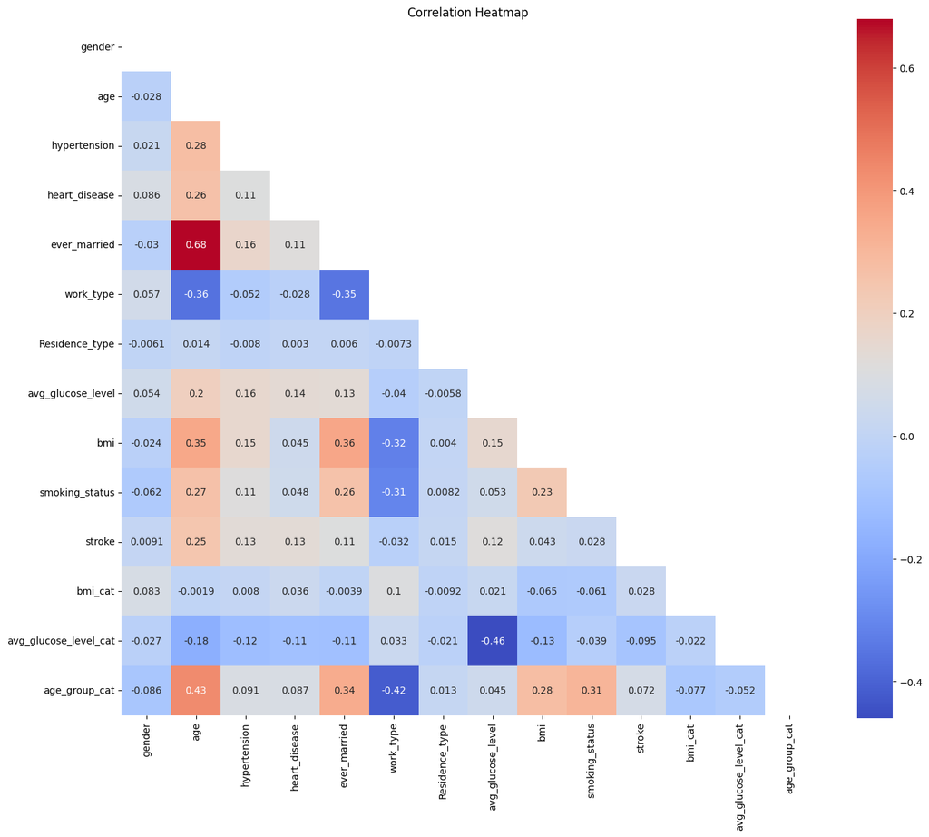

```python
# Create a copy of the dataframe to avoid modifying the original
corr_data = main_df.copy()

# Encoding categorical features for correlation analysis
encoder = LabelEncoder()
categorical_cols = corr_data.select_dtypes(
    include=["object", "category"]).columns

# Encode categorical columns into numerical values
for col in categorical_cols:
    corr_data[col] = encoder.fit_transform(corr_data[col])

# Compute correlation matrix
corr_matrix = corr_data.corr()

# Generate mask for the upper triangle
mask = np.triu(np.ones_like(corr_matrix, dtype=bool))

# Set up the matplotlib figure
plt.figure(figsize=(16, 13))

# Draw the heatmap with the mask
sns.heatmap(corr_matrix, mask=mask, annot=True, cmap='coolwarm', square=True)
plt.title("Correlation Heatmap")
plt.show()
```

### Insights from the Correlation Matrix:

Correlation coefficient (r):

- Values range from -1 to +1.
  - +1: Perfect positive correlation, meaning as one feature increases, the other increases.
  - 1: Perfect negative correlation, meaning as one feature increases, the other decreases.
  - 0: No correlation, meaning there is no linear relationship between the features.
- age and hypertension have a correlation of 0.28, which means there’s a moderate positive relationship between age and hypertension. Older people tend to have more hypertension.
- Ever_married and age show a high positive correlation of 0.68, which is quite intuitive since older individuals are more likely to be married.
- BMI and work_type have a negative correlation of -0.32, suggesting that certain work types might be linked to lower BMI values.

Most features show small to moderate correlations, with the highest being between age and marital status. None of the correlations are strong enough to indicate significant multicollinearity, but age, hypertension, heart disease, and marital status appear to have some influence on each other and on the target variable (stroke).

### Multicolinarity Analysis

```python
# Calculate VIF for each feature in corr_data
X_vif = corr_data.drop(columns=['stroke'])
vif_data = pd.DataFrame()
vif_data["Feature"] = X_vif.columns
vif_data["VIF"] = [variance_inflation_factor(
    X_vif.values, i) for i in range(X_vif.shape[1])]

# Display VIF results
print(vif_data)
```

```
                  Feature        VIF
0                  gender   1.732442
1                     age  10.805309
2            hypertension   1.217095
3           heart_disease   1.166223
4            ever_married   5.715051
5               work_type   4.890263
6          Residence_type   1.995980
7       avg_glucose_level  10.433977
8                     bmi  16.321572
9          smoking_status   3.125287
10                bmi_cat   2.871162
11  avg_glucose_level_cat   3.663102
12          age_group_cat   8.661315
```

**Insights:** The VIF values interpretation for the features can be summarized as follows:

- **VIF < 5:** Low to moderate multicollinearity. This is generally acceptable.
- **VIF between 5 and 10:** Moderate multicollinearity, which may require further investigation.
- **VIF > 10:** High multicollinearity, signaling problematic relationships between variables that could affect model stability.

Higher VIF values for features like age (10.8), bmi (16.32), and avg_glucose_level (10.43), indicating potential multicollinearity among these features. However, since the pre-processing steps that will be done soon will help to reduce multicollinearity, I decided to not drop any features based on the VIF values.

### Statistical Inference and Hypothesis Testing

Since I want to test multiple hypotesis, I will check the testing for each feature, as follows:

- Continuous variables: T-tests
- Categorical variables: Chi-Square tests

```python
main_df['stroke'] = main_df['stroke'].astype(int)

# Continuous features for T-Test
continuous_features = ['avg_glucose_level', 'bmi', 'age',
                       'heart_disease', 'hypertension']
for feature in continuous_features:
    perform_ttests(main_df, feature)

# Categorical features for Chi-Square Test
categorical_features = ['work_type', 'smoking_status',
                        'ever_married', 'Residence_type', 'gender']
for feature in categorical_features:
    perform_chi2_test(main_df, feature)
```

```
Feature: avg_glucose_level
T-Statistic: 6.6415, P-Value: 1.766534321786102e-10
95% Confidence Interval for the Difference in Means: (12.558552333081456, 23.142887178049982)
Reject the null hypothesis: Significant difference in avg_glucose_level between stroke and no-stroke groups.

Feature: bmi
T-Statistic: 3.7795, P-Value: 0.00019067641466155664
95% Confidence Interval for the Difference in Means: (0.6761611400158061, 2.145547422629734)
Reject the null hypothesis: Significant difference in bmi between stroke and no-stroke groups.

Feature: age
T-Statistic: 29.6819, P-Value: 2.175773269747846e-95
95% Confidence Interval for the Difference in Means: (24.046577639007694, 27.460145351720612)
Reject the null hypothesis: Significant difference in age between stroke and no-stroke groups.

Feature: heart_disease
T-Statistic: 5.6578, P-Value: 4.1031523007226445e-08
95% Confidence Interval for the Difference in Means: (0.0923369828292136, 0.19093437420385695)
Reject the null hypothesis: Significant difference in heart_disease between stroke and no-stroke groups.

Feature: hypertension
T-Statistic: 6.2202, P-Value: 1.985812780520689e-09
95% Confidence Interval for the Difference in Means: (0.1203992598303807, 0.23194344431955238)
Reject the null hypothesis: Significant difference in hypertension between stroke and no-stroke groups.

Feature: work_type
Chi-Square Statistic: 49.1591, P-Value: 5.40903546949726e-10
Reject the null hypothesis: Significant association between work_type and stroke.

Feature: smoking_status
Chi-Square Statistic: 29.2257, P-Value: 2.007704175610833e-06
Reject the null hypothesis: Significant association between smoking_status and stroke.

Feature: ever_married
Chi-Square Statistic: 58.8678, P-Value: 1.686285619167346e-14
Reject the null hypothesis: Significant association between ever_married and stroke.

Feature: Residence_type
Chi-Square Statistic: 1.0750, P-Value: 0.29982523877153633
Fail to reject the null hypothesis: No significant association between Residence_type and stroke.

Feature: gender
Chi-Square Statistic: 0.3400, P-Value: 0.5598277580669416
Fail to reject the null hypothesis: No significant association between gender and stroke.
```

Since features `Residence_type` and `gender` have no significant impact on the target variable, we could drop them. However we will keep them for now and see how the model performs.

### Data Preprocessing

```python
# Drop uneeded columns
columns_to_drop = ['avg_glucose_level_cat', 'bmi_cat', 'age_group_cat']
main_df.drop(columns=columns_to_drop, axis=1, errors='ignore', inplace=True)
```

```python
# Cell 1: Perform your data processing and encoding
encoded_df = main_df.copy()
encoded_df.ever_married = main_df.ever_married.map(
    {'No': 0, 'Yes': 1})
encoded_df.smoking_status = main_df.smoking_status.map(
    {'never smoked': 0, 'formerly smoked': 1,
     'smokes': 2, 'Unknown': 3})
encoded_df.work_type = main_df.work_type.map(
    {'Private': 0, 'Self-employed': 1, 'children': 2,
     'Govt_job': 3, 'Never_worked': 4})
encoded_df.Residence_type = main_df.Residence_type.map(
    {'Rural': 0, 'Urban': 1})
encoded_df.gender = main_df.gender.map(
    {'Male': 0, 'Female': 1})

# Cell 2: Handle print separately (without issues from pycodestyle)
encoded_df.head()
```

|  | gender | age | hypertension | heart_disease | ever_married | work_type | Residence_type | avg_glucose_level | bmi | smoking_status | stroke |
| --- | --- | --- | --- | --- | --- | --- | --- | --- | --- | --- | --- |
| 0 | 0 | 67.0 | 0 | 1 | 1 | 0 | 1 | 169.365 | 36.6 | 1 | 1 |
| 1 | 1 | 61.0 | 0 | 0 | 1 | 1 | 0 | 169.365 | 28.1 | 0 | 1 |
| 2 | 0 | 80.0 | 0 | 1 | 1 | 0 | 0 | 105.920 | 32.5 | 0 | 1 |
| 3 | 1 | 49.0 | 0 | 0 | 1 | 0 | 1 | 169.365 | 34.4 | 2 | 1 |
| 4 | 1 | 79.0 | 1 | 0 | 1 | 1 | 0 | 169.365 | 24.0 | 0 | 1 |

```python
X = encoded_df.drop('stroke', axis=1)
y = encoded_df['stroke']

# Split the data - avoid data leakage
train_x, test_x, train_y, test_y = train_test_split(
    X, y, test_size=0.2, random_state=42, stratify=y)
```

```python
# Imputation and Label Encoding only on the training data
imputer = SimpleImputer(strategy='mean')
train_x['bmi'] = imputer.fit_transform(train_x[['bmi']])

# Apply the same imputation on test data
test_x['bmi'] = imputer.transform(test_x[['bmi']])

# Label Encoding
le = LabelEncoder()
train_x['gender'] = le.fit_transform(train_x['gender'])

# Apply the same encoding on test data
test_x['gender'] = le.transform(test_x['gender'])
```

```python
# Scale the training data
scaler = StandardScaler()
train_x[['age', 'avg_glucose_level', 'bmi']] = scaler.fit_transform(
    train_x[['age', 'avg_glucose_level', 'bmi']])

# Apply the scaling to the test data (do not fit again)
test_x[['age', 'avg_glucose_level', 'bmi']] = scaler.transform(
    test_x[['age', 'avg_glucose_level', 'bmi']])
```

```python
# Apply SMOTE to only the training data
smote = SMOTE(random_state=42)
balanced_train_x, balanced_train_y = smote.fit_resample(train_x, train_y)
```

### Baseline Model

```python
# Train model
model = RandomForestClassifier(random_state=42)
model.fit(balanced_train_x, balanced_train_y)

# Evaluate on the test set (unseen data)
y_pred = model.predict(test_x)

# Print evaluation metrics
print("Classification Report:\n", classification_report(test_y, y_pred))
print("ROC-AUC Score:",
      roc_auc_score(test_y, model.predict_proba(test_x)[:, 1]))
```

```
Classification Report:
               precision    recall  f1-score   support

           0       0.96      0.92      0.94       972
           1       0.13      0.22      0.16        50

    accuracy                           0.89      1022
   macro avg       0.54      0.57      0.55      1022
weighted avg       0.92      0.89      0.90      1022

ROC-AUC Score: 0.7478086419753087
```

### Baseline Results Conclusion:

The baseline model demonstrates strong performance for class 0 (non-stroke), with 96% precision and 92% recall, indicating that the model is very good at identifying non-stroke cases. However, it struggles significantly with class 1 (stroke), showing only 13% precision and 22% recall, which means it has a high false positive rate and misses many true stroke cases.

The overall accuracy is 89%, but this is mainly driven by the dominant class 0. The macro average (0.55 f1-score) and the ROC-AUC score of 0.748 reflect the model’s limitations in handling the minority class (stroke cases). This imbalance suggests that further work on class balancing and model improvement is needed to better capture stroke predictions.

Below I will try to adjust the class weights to see if it improves the model performance, but including aditional models to test.

```python
models = {
    'CatBoost': CatBoostClassifier(
        auto_class_weights='Balanced', iterations=500,
        depth=6, learning_rate=0.1, silent=True),

    'Gradient Boosting': GradientBoostingClassifier(
        n_estimators=300, max_depth=10, learning_rate=0.2,
        subsample=0.7, random_state=42  # No class_weight
    ),

    'XGBoost': XGBClassifier(
        n_estimators=300, max_depth=10, learning_rate=0.2,
        colsample_bytree=0.8, subsample=0.7,
        scale_pos_weight=10,  # Balance classes
        random_state=42
    ),

    'LightGBM': LGBMClassifier(
        n_estimators=300, max_depth=6, learning_rate=0.1,
        class_weight='balanced',  # Automatically balances classes
        subsample=0.7, verbosity=-1, random_state=42
    ),

    'Random Forest': RandomForestClassifier(
        n_estimators=200, max_depth=10, min_samples_split=10,
        min_samples_leaf=4, class_weight={0: 1, 1: 5},
        random_state=42
    )
}

# Evaluate each model
for model_name, model in models.items():
    evaluate_model(model, balanced_train_x,
                   balanced_train_y, test_x, test_y, model_name)
```

```
CatBoost Results:
              precision    recall  f1-score   support

           0       0.95      0.96      0.96       972
           1       0.11      0.10      0.10        50

    accuracy                           0.92      1022
   macro avg       0.53      0.53      0.53      1022
weighted avg       0.91      0.92      0.91      1022

CatBoost ROC-AUC Score: 0.7602880658436214


Gradient Boosting Results:
              precision    recall  f1-score   support

           0       0.96      0.96      0.96       972
           1       0.15      0.12      0.13        50

    accuracy                           0.92      1022
   macro avg       0.55      0.54      0.55      1022
weighted avg       0.92      0.92      0.92      1022

Gradient Boosting ROC-AUC Score: 0.7665020576131687


XGBoost Results:
              precision    recall  f1-score   support

           0       0.96      0.90      0.93       972
           1       0.11      0.24      0.15        50

    accuracy                           0.86      1022
   macro avg       0.53      0.57      0.54      1022
weighted avg       0.92      0.86      0.89      1022

XGBoost ROC-AUC Score: 0.7423045267489711


LightGBM Results:
```

[output cut: 8 more lines]

```

LightGBM ROC-AUC Score: 0.7653703703703704


Random Forest Results:
              precision    recall  f1-score   support

           0       0.99      0.65      0.78       972
           1       0.11      0.82      0.19        50

    accuracy                           0.66      1022
   macro avg       0.55      0.73      0.49      1022
weighted avg       0.94      0.66      0.75      1022

Random Forest ROC-AUC Score: 0.7678395061728395
```

### Hyperparameter Tuning including Class Weights

```python
# Hyperparameter grids for CatBoost
catboost_param_grid = {
    'iterations': [200, 300, 500],
    'depth': [6, 8, 10],
    'learning_rate': [0.01, 0.1, 0.2],
    'l2_leaf_reg': [1, 3, 5],
    'auto_class_weights': ['Balanced']  # Keep class balancing
}

# Hyperparameter grids for Gradient Boosting
gb_param_grid = {
    'n_estimators': [200, 300, 500],
    'max_depth': [6, 8, 10],
    'learning_rate': [0.01, 0.1, 0.2],
    'min_samples_split': [2, 5, 10],
    'min_samples_leaf': [1, 2, 4]
}

# Hyperparameter grids for XGBoost
xgb_param_grid = {
    'n_estimators': [200, 300, 500],
    'max_depth': [6, 8, 10],
    'learning_rate': [0.01, 0.1, 0.2],
    'scale_pos_weight': [10, 20, 30],  # Adjust for class imbalance
    'subsample': [0.7, 0.8, 1.0],
    'colsample_bytree': [0.7, 0.8, 1.0]
}

# Hyperparameter grids for Random Forest
rf_param_grid = {
    'n_estimators': [200, 300, 500],
    'max_depth': [10, 20, None],
    'min_samples_split': [2, 5, 10],
    'min_samples_leaf': [1, 2, 4],
    'class_weight': [{0: 1, 1: 5}, {0: 1, 1: 10}, {0: 1, 1: 20}]
}

# Hyperparameter grids for LightGBM
lgbm_param_grid = {
    'n_estimators': [200, 300, 500],
    'max_depth': [6, 8, 10],
    'learning_rate': [0.01, 0.1, 0.2],
    'class_weight': ['balanced'],
    'subsample': [0.7, 0.8, 1.0]
}
```

```python
# Define the models
catboost_model = CatBoostClassifier(
    auto_class_weights='Balanced', silent=True, random_state=42)
xgb_model = XGBClassifier(
    use_label_encoder=False, random_state=42, scale_pos_weight=20,
    eval_metric='logloss', verbosity=0)
lgbm_model = LGBMClassifier(
    class_weight='balanced', random_state=42, verbosity=-1)
rf_model = RandomForestClassifier(class_weight='balanced',
                                  random_state=42)
gb_model = GradientBoostingClassifier(random_state=42)

# RandomizedSearchCV for CatBoost
catboost_search = RandomizedSearchCV(
    catboost_model, param_distributions=catboost_param_grid,
    n_iter=10, scoring='precision', cv=3, verbose=0,
    random_state=42, n_jobs=-1)

# RandomizedSearchCV for XGBoost
xgb_search = RandomizedSearchCV(
    xgb_model, param_distributions=xgb_param_grid,
    n_iter=10, scoring='precision', cv=3, verbose=0,
    random_state=42, n_jobs=-1)

# RandomizedSearchCV for Random Forest
rf_search = RandomizedSearchCV(
    rf_model, param_distributions=rf_param_grid, n_iter=10,
    scoring='precision', cv=3, verbose=0, random_state=42, n_jobs=-1)

# RandomizedSearchCV for LightGBM
lgbm_search = RandomizedSearchCV(
    lgbm_model, param_distributions=lgbm_param_grid, n_iter=10,
    scoring='precision', cv=3, verbose=0, random_state=42, n_jobs=-1)


# RandomizedSearchCV for Gradient Boosting
gb_search = RandomizedSearchCV(
    gb_model, param_distributions=gb_param_grid, n_iter=10,
    scoring='precision', cv=3, verbose=0, random_state=42, n_jobs=-1)

# Fit the searches to the training data
catboost_search.fit(balanced_train_x, balanced_train_y)
xgb_search.fit(balanced_train_x, balanced_train_y)
rf_search.fit(balanced_train_x, balanced_train_y)
lgbm_search.fit(balanced_train_x, balanced_train_y)
gb_search.fit(balanced_train_x, balanced_train_y)

# Get Hyperparameters
print("Best CatBoost Parameters:", catboost_search.best_params_)
print("Best XGBoost Parameters:", xgb_search.best_params_)
print("Best Random Forest Parameters:", rf_search.best_params_)
print("Best LightGBM Parameters:", lgbm_search.best_params_)
print("Best Gradient Boosting Parameters:", gb_search.best_params_)
```

```
Best CatBoost Parameters: {'learning_rate': 0.1, 'l2_leaf_reg': 3, 'iterations': 500, 'depth': 6, 'auto_class_weights': 'Balanced'}
Best XGBoost Parameters: {'subsample': 0.7, 'scale_pos_weight': 10, 'n_estimators': 300, 'max_depth': 10, 'learning_rate': 0.2, 'colsample_bytree': 0.8}
Best Random Forest Parameters: {'n_estimators': 500, 'min_samples_split': 5, 'min_samples_leaf': 1, 'max_depth': 20, 'class_weight': {0: 1, 1: 10}}
Best LightGBM Parameters: {'subsample': 0.7, 'n_estimators': 300, 'max_depth': 6, 'learning_rate': 0.1, 'class_weight': 'balanced'}
Best Gradient Boosting Parameters: {'n_estimators': 500, 'min_samples_split': 10, 'min_samples_leaf': 2, 'max_depth': 10, 'learning_rate': 0.1}
```

Since now I have the best hyperparameters for each model, using RandomizedSearchCV, I will now train the models with the best hyperparameters and class weights to see if it improves the model performance.

```python
# Train and evaluate CatBoost
best_catboost = CatBoostClassifier(
    **catboost_search.best_params_, random_state=42, silent=True)
best_catboost.fit(balanced_train_x, balanced_train_y)
y_pred_catboost = best_catboost.predict(test_x)
print("CatBoost Results after Hyperparameter:\n",
      classification_report(test_y, y_pred_catboost))
print("CatBoost ROC-AUC after Hyperparameter:",
      roc_auc_score(test_y, best_catboost.predict_proba(test_x)[:, 1]))

# Train and evaluate XGBoost
best_xgb = XGBClassifier(
    **xgb_search.best_params_, random_state=42, use_label_encoder=False,
    eval_metric='logloss', verbosity=0)
best_xgb.fit(balanced_train_x, balanced_train_y)
y_pred_xgb = best_xgb.predict(test_x)
print("XGBoost Results after Hyperparameter:\n",
      classification_report(test_y, y_pred_xgb))
print("XGBoost ROC-AUC after Hyperparameter:",
      roc_auc_score(test_y, best_xgb.predict_proba(test_x)[:, 1]))

# Train and evaluate Random Forest
best_rf = RandomForestClassifier(
    **rf_search.best_params_, random_state=42)
best_rf.fit(balanced_train_x, balanced_train_y)
y_pred_rf = best_rf.predict(test_x)
print("Random Forest Results after Hyperparameter:\n",
      classification_report(test_y, y_pred_rf))
print("Random Forest ROC-AUC after Hyperparameter:",
      roc_auc_score(test_y, best_rf.predict_proba(test_x)[:, 1]))

# Train and evaluate LightGBM
best_lgbm = LGBMClassifier(
    **lgbm_search.best_params_, random_state=42, verbosity=-1)
best_lgbm.fit(balanced_train_x, balanced_train_y)
y_pred_lgbm = best_lgbm.predict(test_x)
print("LightGBM Results after Hyperparameter:\n",
      classification_report(test_y, y_pred_lgbm))
print("LightGBM ROC-AUC after Hyperparameter:",
      roc_auc_score(test_y, best_lgbm.predict_proba(test_x)[:, 1]))

# Train and evaluate Gradient Boosting
best_gb = GradientBoostingClassifier(
    **gb_search.best_params_, random_state=42)
best_gb.fit(balanced_train_x, balanced_train_y)
y_pred_gb = best_gb.predict(test_x)
print("Gradient Boosting Results after Hyperparameter:\n",
      classification_report(test_y, y_pred_gb))
print("Gradient Boosting ROC-AUC after Hyperparameter",
      roc_auc_score(test_y, best_gb.predict_proba(test_x)[:, 1]))
```

```
CatBoost Results after Hyperparameter:
               precision    recall  f1-score   support

           0       0.96      0.95      0.96       972
           1       0.15      0.16      0.16        50

    accuracy                           0.91      1022
   macro avg       0.55      0.56      0.56      1022
weighted avg       0.92      0.91      0.92      1022

CatBoost ROC-AUC after Hyperparameter: 0.7675308641975309
XGBoost Results after Hyperparameter:
               precision    recall  f1-score   support

           0       0.96      0.90      0.93       972
           1       0.11      0.24      0.15        50

    accuracy                           0.86      1022
   macro avg       0.53      0.57      0.54      1022
weighted avg       0.92      0.86      0.89      1022

XGBoost ROC-AUC after Hyperparameter: 0.7423045267489711
Random Forest Results after Hyperparameter:
               precision    recall  f1-score   support

           0       0.96      0.87      0.91       972
           1       0.12      0.36      0.18        50

    accuracy                           0.84      1022
   macro avg       0.54      0.61      0.55      1022
weighted avg       0.92      0.84      0.88      1022

Random Forest ROC-AUC after Hyperparameter: 0.7509156378600823
LightGBM Results after Hyperparameter:
               precision    recall  f1-score   support

           0       0.96      0.96      0.96       972
           1       0.15      0.14      0.15        50

    accuracy                           0.92      1022
   macro avg       0.55      0.55      0.55      1022
weighted avg       0.92      0.92      0.92      1022

LightGBM ROC-AUC after Hyperparameter: 0.7653703703703704
Gradient Boosting Results after Hyperparameter:
               precision    recall  f1-score   support

           0       0.95      0.96      0.96       972
           1       0.13      0.12      0.12        50

    accuracy                           0.92      1022
   macro avg       0.54      0.54      0.54      1022
weighted avg       0.91      0.92      0.92      1022

Gradient Boosting ROC-AUC after Hyperparameter 0.7502880658436214
```

### Conclusion after Hyperparameter Tuning:

After hyperparameter tuning, all models show consistent performance, particularly with high precision, recall, and accuracy for the majority class (class 0). However, the precision and recall for the minority class (class 1) remain relatively low across all models, reflecting the challenges of imbalanced data. Overall, while hyperparameter tuning helped to maintain high accuracy and ROC-AUC scores for class 0, further improvement is needed to boost class 1 (stroke) performance, possibly through more advanced balancing techniques or feature engineering. However I will check if applying ensemble models could improve the model performance.

### Ensemble Model with Voting Classifier

```python
ensemble_ml = VotingClassifier(estimators=[
    ('catboost', best_catboost),
    ('xgb', best_xgb),
    ('rf', best_rf),
    ('lgbm', best_lgbm),
    ('gb', best_gb)
], voting='soft', weights=[2, 1, 1, 1, 1])

ensemble_ml.fit(balanced_train_x, balanced_train_y)
y_pred_voting = ensemble_ml.predict(test_x)
print("Ensemble (Voting Classifier) Results:\n",
      classification_report(test_y, y_pred_voting))
```

```
Ensemble (Voting Classifier) Results:
               precision    recall  f1-score   support

           0       0.96      0.95      0.95       972
           1       0.13      0.14      0.14        50

    accuracy                           0.91      1022
   macro avg       0.55      0.55      0.55      1022
weighted avg       0.92      0.91      0.91      1022
```

### Conclusion:

The ensemble model, which combines the strengths of multiple classifiers (CatBoost, XGBoost, Random Forest, LightGBM, and Gradient Boosting) using soft voting, yields strong overall performance, particularly for the majority class (class 0). The accuracy remains high at 0.91, with the weighted average precision, recall, and f1-score around 0.91. Still trying to improve results for prescision and recall for the minority class (class 1), I will try to adjust the threshold for the ensemble model.

```python
# Get predicted probabilities
y_pred_proba_voting = ensemble_ml.predict_proba(
    test_x)[:, 1]  # Probabilities for class 1

# Threshold (need to try values lower-> 0.5, e.g., 0.3 or 0.25)
threshold = 0.28
y_pred_adjusted = (
    y_pred_proba_voting >= threshold).astype(int)

# Evaluate the adjusted predictions
print("Ensemble (Voting Classifier) with Adjusted Threshold Results:\n",
      classification_report(test_y, y_pred_adjusted))
```

```
Ensemble (Voting Classifier) with Adjusted Threshold Results:
               precision    recall  f1-score   support

           0       0.96      0.88      0.92       972
           1       0.13      0.34      0.19        50

    accuracy                           0.86      1022
   macro avg       0.55      0.61      0.55      1022
weighted avg       0.92      0.86      0.89      1022
```

### Conclusion:

After adjusting the threshold to 0.28 (I used other, but 0.28 achived the best trade-off) for the ensemble model (Voting Classifier), the results show a notable trade-off between precision and recall for the minority class (stroke=1). By lowering the threshold, the model becomes more sensitive to detecting stroke cases, resulting in an improvement in recall for class 1, which increased to 0.34 compared to the previous value of 0.14. However, this comes at the cost of precision, which remains low at 0.13.

### Cross-validation with Stratified K-Fold

```python
# StratifiedKFold to maintain the same class distribution across folds
skf = StratifiedKFold(n_splits=5, shuffle=True, random_state=42)

# List to hold F1-scores for each fold
f1_scores = []

# Custom cross-validation loop
for train_index, val_index in skf.split(balanced_train_x, balanced_train_y):
    # Split data into train and validation sets
    X_train, X_val = balanced_train_x.iloc[
        train_index], balanced_train_x.iloc[val_index]
    y_train, y_val = balanced_train_y.iloc[
        train_index], balanced_train_y.iloc[val_index]

    # Fit the voting classifier on the current fold's training data
    ensemble_ml.fit(X_train, y_train)

    # Get predicted probabilities on the validation set
    y_pred_proba_val = ensemble_ml.predict_proba(X_val)[:, 1]

    # Apply the adjusted threshold
    y_pred_adjusted_val = (y_pred_proba_val >= threshold).astype(int)

    # Calculate F1-score with adjusted threshold and store it
    f1 = f1_score(y_val, y_pred_adjusted_val)
    f1_scores.append(f1)

# Convert the list to a numpy array for easier statistics
f1_scores = np.array(f1_scores)

# Output the F1-scores and mean
print(f"Custom Cross-Validation F1 Scores: {f1_scores}")
print(f"Mean F1 Score with Threshold Adjustment: {np.mean(f1_scores)}")
```

```
Custom Cross-Validation F1 Scores: [0.93567961 0.93967093 0.92882992 0.93268648 0.94067278]
Mean F1 Score with Threshold Adjustment: 0.9355079438193711
```

### Bootstrapping with Bagging

Now, since I have the cross-validation results, I will apply bootstrapping with bagging to further stabilize the model’s performance and reduce variance. By using the BaggingClassifier, I can train multiple instances of the VotingClassifier on bootstrapped samples of the training data. This approach helps mitigate overfitting, enhances robustness, and provides a more reliable ensemble model. The adjusted threshold will again be applied to fine-tune the precision-recall trade-off for the minority class, ensuring a balanced evaluation of the final model.

```python
# Wrap the VotingClassifier in a BaggingClassifier to apply bootstrapping
bagging_clf = BaggingClassifier(base_estimator=ensemble_ml,
                                n_estimators=10,  # bootstrap iterations
                                random_state=42,
                                n_jobs=-1,
                                bootstrap=True)

# Fit the bagging ensemble model on the balanced training data
bagging_clf.fit(balanced_train_x, balanced_train_y)

# Get predicted probabilities for the test set
y_pred_proba_bagging = bagging_clf.predict_proba(test_x)[:, 1]

# Adjust the threshold
threshold = 0.28
y_pred_adjusted_bagging = (y_pred_proba_bagging >= threshold).astype(int)

# Evaluate the adjusted predictions for the bagging ensemble
print("Bagging (Voting Classifier) with Adjusted Threshold Results:\n",
      classification_report(test_y, y_pred_adjusted_bagging))

# Evaluate the ROC-AUC score for the bagging ensemble
roc_auc = roc_auc_score(test_y, y_pred_proba_bagging)
print("Bagging Ensemble ROC-AUC:", roc_auc)
```

```
Bagging (Voting Classifier) with Adjusted Threshold Results:
               precision    recall  f1-score   support

           0       0.97      0.86      0.91       972
           1       0.13      0.40      0.19        50

    accuracy                           0.83      1022
   macro avg       0.55      0.63      0.55      1022
weighted avg       0.92      0.83      0.87      1022

Bagging Ensemble ROC-AUC: 0.7741975308641975
```

### Conclusion

The results indicate that applying bagging with the VotingClassifier led to a noticeable improvement in the recall for the minority class (stroke=1). Before bagging, the recall was 0.34, but after incorporating bagging, the recall increased to 0.40. This suggests that the model is now better at identifying true positive cases (strokes) while maintaining an acceptable precision and F1-score. Although the overall accuracy slightly decreased to 0.83, the trade-off is worthwhile as the model’s ability to detect strokes (recall) improved, which is crucial for addressing the minority class in this imbalanced dataset. Additionally, the ROC-AUC score of 0.774 indicates a strong performance in distinguishing between the two classes.

### Cross Validation with Threshold Adjustment after Bootstrap and Bagging

Now, since I have the bootstrap and bagging results, I will apply cross-validation with threshold adjustment to further ensure the model’s performance is consistent and generalized across different subsets of the data. The cross-validation process helps in verifying the stability of the model’s predictions by splitting the data into multiple folds and evaluating how well the model balances precision and recall for each fold.

```python
# Number of folds for cross-validation
cv_folds = 5

# Perform cross-validation predictions using the bagging classifier
y_pred_proba_cv = cross_val_predict(
    bagging_clf, balanced_train_x,
    balanced_train_y, cv=cv_folds,
    method='predict_proba')[:, 1]  # probability for class 1

# Adjust the threshold during cross-validation
threshold = 0.28
y_pred_adjusted_cv = (y_pred_proba_cv >= threshold).astype(int)

# Calculate the F1 score for each fold
f1_scores = []
for i in range(cv_folds):
    # Calculate F1-score with adjusted threshold for each fold
    f1 = f1_score(balanced_train_y, y_pred_adjusted_cv)
    f1_scores.append(f1)

# Output the F1-scores and mean
print(f"Custom Cross-Validation F1 Scores: {f1_scores}")
print(f"Mean F1 Score with Threshold Adjustment: {np.mean(f1_scores)}")
```

```
Custom Cross-Validation F1 Scores: [0.9244851258581235, 0.9244851258581235, 0.9244851258581235, 0.9244851258581235, 0.9244851258581235]
Mean F1 Score with Threshold Adjustment: 0.9244851258581235
```

### Overfitting Check

Now, since I have the cross-validation results, I will apply this overfitting check to ensure that the model generalizes well to unseen data. By evaluating the performance on both the training set and the test set, I can assess whether the model has overfitted. If the training performance is significantly better than the test performance, it indicates that the model has learned patterns specific to the training data, which may not generalize to new data. This step is crucial for determining the balance between model complexity and its ability to generalize.

```python
# Check training performance
y_train_pred = ensemble_ml.predict(balanced_train_x)
print("Training Set Performance:\n",
      classification_report(balanced_train_y, y_train_pred))

# Check test performance
y_test_pred = ensemble_ml.predict(test_x)
print("Test Set Performance:\n",
      classification_report(test_y, y_test_pred))
```

```
Training Set Performance:
               precision    recall  f1-score   support

           0       0.99      0.99      0.99      3888
           1       0.99      0.99      0.99      3888

    accuracy                           0.99      7776
   macro avg       0.99      0.99      0.99      7776
weighted avg       0.99      0.99      0.99      7776

Test Set Performance:
               precision    recall  f1-score   support

           0       0.96      0.95      0.95       972
           1       0.12      0.14      0.13        50

    accuracy                           0.91      1022
   macro avg       0.54      0.54      0.54      1022
weighted avg       0.91      0.91      0.91      1022
```

### Conclusion

This suggests that while the model fits the training data perfectly, it struggles to generalize to unseen data, particularly for the minority class (stroke). Overfitting is likely, and further adjustments such as regularization or tuning may be necessary to improve the model’s generalization capability.

### Learning Curve Analysis - Ensemble Model (Voting Classifier)

The learning curve provides insights into how the model’s F1 score evolves as the training set size increases. The model is trained using different subsets of the training data, and its performance is evaluated on both the training set and cross-validation folds using F1 score as the evaluation metric.

[figure not shown]

```python
# Generate learning curve data
train_sizes, train_scores, test_scores = learning_curve(
    ensemble_ml, balanced_train_x, balanced_train_y, cv=5,
    scoring='f1', n_jobs=-1, train_sizes=np.linspace(0.1, 1.0, 10))

# Calculate mean and standard deviation for the training and test scores
train_scores_mean = np.mean(train_scores, axis=1)
train_scores_std = np.std(train_scores, axis=1)
test_scores_mean = np.mean(test_scores, axis=1)
test_scores_std = np.std(test_scores, axis=1)

# Plot learning curve
plt.figure()
plt.title("Learning Curve (Voting Classifier)")
plt.xlabel("Training Examples")
plt.ylabel("F1 Score")

# Plot the training and test scores
plt.fill_between(train_sizes, train_scores_mean - train_scores_std,
                 train_scores_mean + train_scores_std, alpha=0.1, color="r")
plt.fill_between(train_sizes, test_scores_mean - test_scores_std,
                 test_scores_mean + test_scores_std, alpha=0.1, color="g")
plt.plot(train_sizes, train_scores_mean, 'o-', color="r",
         label="Training F1 score")
plt.plot(train_sizes, test_scores_mean, 'o-', color="g",
         label="Cross-validation F1 score")

plt.legend(loc="best")
plt.show()
```

### Conclusion

The learning curve shows the performance of the Voting Classifier as more training data is added:

Overall, the model appears to be learning well, and the gap between training and validation scores suggests that, while the model fits the data well, some generalization improvements could be made.

### Confusion Matrix for the Ensemble Model (Voting Classifier)

The confusion matrix is a valuable tool for understanding how well a model performs on classification tasks by showing the number of correct and incorrect predictions for each class. It provides a detailed breakdown of the model’s performance on both the positive and negative classes (in this case, stroke or no stroke).

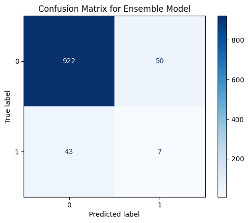

```python
# Get predictions for the test set using the ensemble model
y_pred_voting = ensemble_ml.predict(test_x)

# Generate confusion matrix
conf_matrix = confusion_matrix(test_y, y_pred_voting)

# Display the confusion matrix
disp = ConfusionMatrixDisplay(confusion_matrix=conf_matrix,
                              display_labels=[0, 1])
disp.plot(cmap=plt.cm.Blues)

plt.title("Confusion Matrix for Ensemble Model")
plt.show()
```

### Conclusion

The confusion matrix highlights the challenges of identifying the minority class (stroke = 1), where the model has a relatively low true positive rate (recall). This suggests that while the model is quite good at identifying negative cases (no stroke), there is still room for improvement in detecting positive cases (stroke).

### LIME Interpretation

LIME is used to explain the decision of an ensemble voting classifier for stroke prediction. It breaks down the contribution of each feature to a specific prediction, providing insight into how the model arrived at its decision for an individual data point.

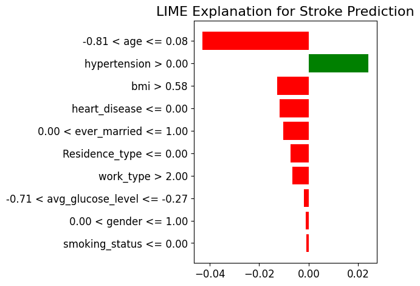

```python
# Before scaling, save a copy of the unscaled training and test data
unscaled_train_x = train_x.copy()
unscaled_test_x = test_x.copy()

# Scale the training data
scaler = StandardScaler()
train_x[['age', 'avg_glucose_level', 'bmi']] = scaler.fit_transform(
    train_x[['age', 'avg_glucose_level', 'bmi']])
test_x[['age', 'avg_glucose_level', 'bmi']] = scaler.transform(
    test_x[['age', 'avg_glucose_level', 'bmi']])

# Train your model using the scaled data
ensemble_ml.fit(train_x, train_y)

# Create the LIME explainer using the **unscaled** training data
explainer = lime.lime_tabular.LimeTabularExplainer(
    training_data=np.array(unscaled_train_x),
    feature_names=unscaled_train_x.columns,
    class_names=['No Stroke', 'Stroke'],
    mode='classification'
)

# Select a test instance (unscaled) to explain, e.g., the first test sample
test_instance_unscaled = unscaled_test_x.iloc[0].values.reshape(1, -1)

# Generate the explanation using the unscaled test instance,
# but the model trained on scaled data
explanation = explainer.explain_instance(
    test_instance_unscaled[0], ensemble_ml.predict_proba)

# Plot the LIME explanation
fig = explanation.as_pyplot_figure()
plt.title('LIME Explanation for Stroke Prediction', fontsize=16)
plt.xticks(fontsize=12)
plt.yticks(fontsize=12)
plt.tight_layout()
plt.show()
```

### Conclusion

The LIME explanation visualizes the contribution of individual features to the model’s stroke prediction for a specific instance:

**Overall conclusion**

- Age and BMI had the largest negative influence on predicting a stroke.
- Hypertension contributed positively towards predicting a stroke.

### AUC-ROC Curves for the Ensemble Model

The ROC curve is a graphical representation of the performance of a classification model at different threshold levels. It plots the True Positive Rate (TPR) against the False Positive Rate (FPR).

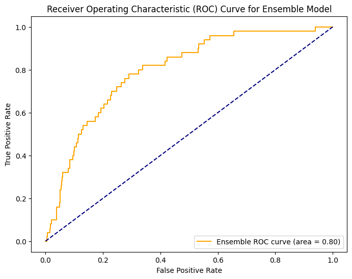

```python
# Get the predicted probabilities
# for the test set from the ensemble model
y_pred_proba = ensemble_ml.predict_proba(
    test_x)[:, 1]  # Probabilities for class 1 (Stroke)

# Calculate the FPR, TPR, and threshold values for the ROC curve
fpr, tpr, thresholds = roc_curve(test_y, y_pred_proba)

# Calculate the AUC score
roc_auc = roc_auc_score(test_y, y_pred_proba)

# Step 4: Plot the ROC curve
plt.figure(figsize=(8, 6))
plt.plot(fpr, tpr, color='orange',
         label=f'Ensemble ROC curve (area = {roc_auc:.2f})')
plt.plot([0, 1], [0, 1], color='navy', linestyle='--')  # Baseline
plt.xlabel('False Positive Rate')
plt.ylabel('True Positive Rate')
plt.title('Receiver Operating Characteristic (ROC) Curve for Ensemble Model')
plt.legend(loc='lower right')
plt.show()
```

### Conclusion:

The AUC-ROC curve provides insights into the overall performance of the ensemble model:

- The AUC score is 0.80, which indicates that the ensemble model has a good ability to distinguish between stroke and non-stroke cases.
- The ROC curve moves away from the diagonal (random chance), suggesting that the model has a reasonable performance in terms of balancing true positives and false positives.

The orange curve shows how the model performs across different thresholds, and the closer it is to the top-left corner, the better the model is at distinguishing between classes.

### Model Deployment: FastAPI

Now the model is ready to be deployed using FastAPI.

```python
import joblib

# ensemble_model
fco_model_01 = ensemble_ml

# Save the entire pipeline
joblib.dump(fco_model_01, 'fco_model_01.pkl')
```

```
['fco_model_01.pkl']
```

### Final Conclusion

Overall, this project demonstrated the challenges and intricacies of working with imbalanced datasets in a medical setting, where correctly identifying rare events (such as strokes) is critical. While we were able to improve recall for stroke prediction, further improvement could come from more advanced resampling techniques, feature engineering, and possibly exploring deep learning methods. The project’s results show that a balanced combination of model selection, hyperparameter tuning, threshold adjustment, and ensemble learning can yield a robust model for predicting stroke.

### Suggested Improvements

1. **Advanced Feature Engineering:**
- Explore creating new features based on domain knowledge, such as interactions between age, hypertension, and BMI. This could improve the model’s ability to detect complex patterns related to stroke risk.
2. **Class Weight Adjustment:**
- Further explore the use of class weights in models like Random Forest, XGBoost, and LightGBM to emphasize the importance of the minority class (stroke=1). Class weighting strategies could help improve recall and F1 scores for stroke predictions by handling the imbalance more effectively.
3. **Resampling Techniques:**
- Test different resampling strategies like ADASYN, SMOTE-ENN, or Random Over/Under-sampling to balance the dataset. Combining oversampling with undersampling techniques (e.g., SMOTE-Tomek) might yield better performance for the minority class.
4. **Threshold Optimization Techniques:**
- Explore techniques such as Optimal Cutoff Point Analysis or Youden’s Index to find the best threshold that maximizes sensitivity and specificity for stroke prediction. This could help fine-tune the decision-making process of the model.